# Stats for Hackers

M. Liu

October 1, 2015

# 0. Introduction

It is all started from this one speaker deck of [Statistics for Hackers](https://speakerdeck.com/jakevdp/statistics-for-hackers) that Colin has shared with us. It has covered the topis below, I have inserted some of the bayesian analysis into each section as the author did mention that he would like to do and *Bayesianism* is the new *sexy* in this field now.

For each section it comes with *classic* frequentism test, *simulation* and *bayesian* when available.

1. hypothesis test
2. split testing aka A/B testing
3. bootstraping
4. cross validation

*Disclaimer*: by no means, any of the below analysis and code would be accurate, it was created for fun after reading through the deck. Therefore, …, would appreciate any feedback, and if you think they are good for your use, go for it.

# 1. Warm-up: coin toss hypothesis testing

22 heads out of 30 coin tosses. Is it a fair coin? How probable to get that?

### 1.1 Classic Frequentist

I could never set my head with those equations, here is the existing function to call and do the propotion test then read the *p value*

```r
prop.test(22, 30, 0.05)
```

```
##
##  1-sample proportions test with continuity correction
##
## data:  22 out of 30, null probability 0.05
## X-squared = 280.7, df = 1, p-value < 2.2e-16
## alternative hypothesis: true p is not equal to 0.05
## 95 percent confidence interval:
##  0.5382722 0.8702456
## sample estimates:
##         p
## 0.7333333
```

### 1.2 Simulation

This seems to be quite straigtforward, but does require a lot computing power if we have fairly large sample size, probably won’t be much practical. In addition, there are a lot existing simulation packages there, that’ll save the hassle on coding. For instance *MCMCpack* for Markov Chain Monte Carlo (*mcmc*) simulation.

```r
N <- 10000
x <- NULL

for(i in 1:N){
  x[i] <- ifelse(sum(sample(c(0,1), 30, replace=T))>=22, 1, 0)
}

sum(x)/N
```

```
## [1] 0.0083
```

# 2. Sneetches of Split Testing

### 2.1 Classic Student’s T Test

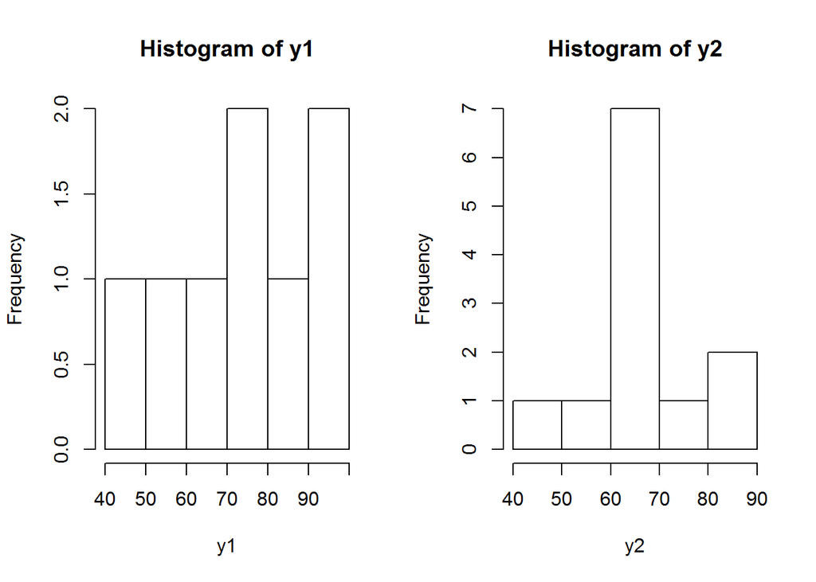

```r
y1 <- c(84, 72, 57, 46, 63, 76, 99, 91)
y2 <- c(81, 69, 74, 61, 56, 87, 69, 65, 66, 44, 62, 69)
par(mfrow=c(1,2))
hist(y1)
hist(y2)
```

```
##
##  Welch Two Sample t-test
##
## data:  y1 and y2
## t = 0.93161, df = 10.696, p-value = 0.3721
## alternative hypothesis: true difference in means is not equal to 0
## 95 percent confidence interval:
##  -9.024137 22.190804
## sample estimates:
## mean of x mean of y
##  73.50000  66.91667
```

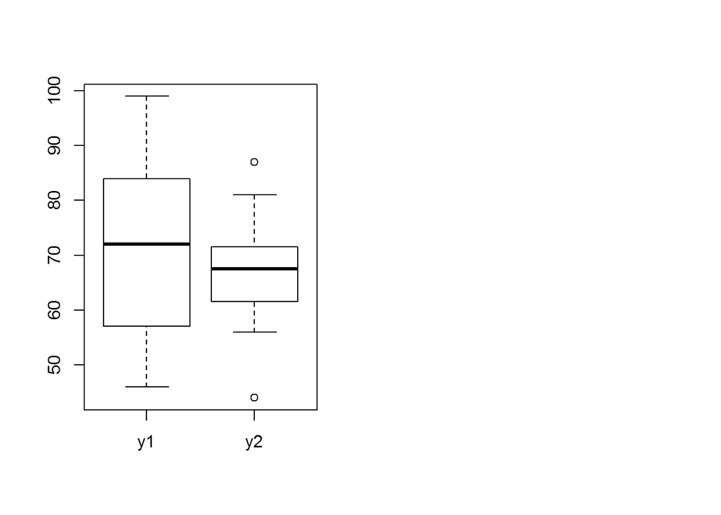

```r
boxplot(as.data.frame(cbind(y1, y2)))
t.test(y1, y2)
```

### 2.2 Bayesian EStimates

The BEST (Bayesian Estimates Supersed t.test) is one of the interesting package. However for serious research and testing, may better off writting *mcmc*

```r
require(BEST, quietly = T)
best.sneetches <- BESTmcmc(y1, y2)
```

```
##
## Processing function input.......
##
## Done.
##
## Beginning parallel processing with 3 clusters. Console output will be suppressed.
##
## Parallel processing completed.
##
## MCMC took 0.145 minutes.
```

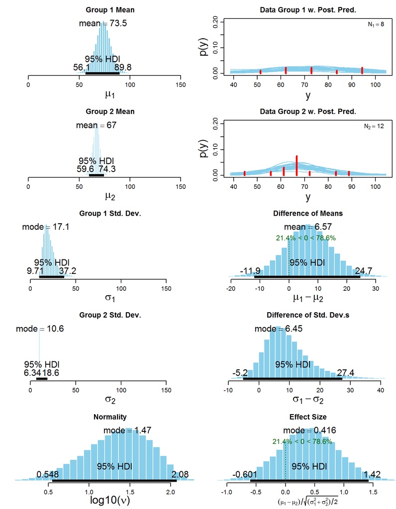

```r
#summary(best.sneetches)
plotAll(best.sneetches)
```

### 2.3 Bayesian Factor

the interpretation of the results is shown in wikipedia page - [Bayes Factor](https://en.wikipedia.org/wiki/Bayes_factor)

Posterior odd ∝ Prior odd * Bayes Factor (likelihood ratio)

Here is the factor:

```r
require(BayesFactor, quietly = T)
bf.sneetches.nopost <- ttestBF(y1, y2)
summary(bf.sneetches.nopost)
```

```
## Bayes factor analysis
## --------------
## [1] Alt., r=0.707 : 0.5781107 ±0%
##
## Against denominator:
##   Null, mu1-mu2 = 0
## ---
## Bayes factor type: BFindepSample, JZS
```

Here is the fancy plots, what does it mean? You tell me.

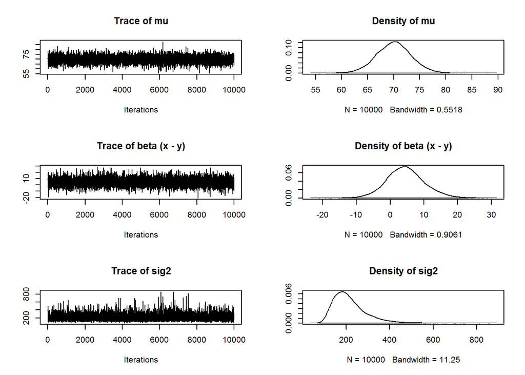

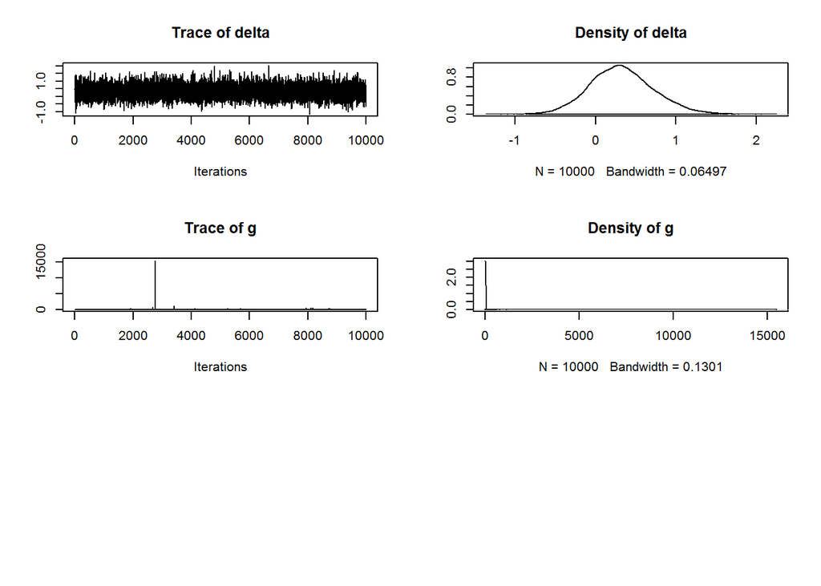

```r
bf.sneetches <- ttestBF(y1, y2, posterior = TRUE, iterations = 10000)
plot(bf.sneetches)
```

### 2.4 shuffling and resampling

difference of the sample mean, and test the standard deviation.

```r
mean(y1) - mean(y2)
```

```
## [1] 6.583333
```

```r
sd(y1) == sd(y2)
```

```
## [1] FALSE
```

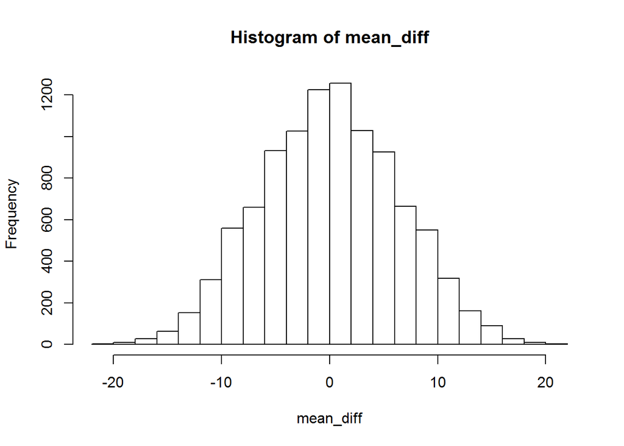

```r
ys <- c(y1, y2)
mean_diff <- NULL
N <- 10000

# drawing random samples out of combined dataset, calculate the mean difference
# repeated for 10,000 times
for(i in 1:N){
  idx <- sample(1:length(ys), 20, replace = F)
  yy <- as.data.frame(cbind(ys, idx))
  mean_diff [i] <- mean(subset(yy, idx<=8)$ys) - mean(subset(yy, idx>8)$ys)
}
hist(mean_diff, breaks=30)
```

# 3. Bootstraping of Yertle turtles

Again, wikipedia is a very good source. Here is the quote: In statistics, bootstrapping can refer to any test or metric that relies on *random sampling with replacement*. Bootstrapping allows assigning measures of accuracy (defined in terms of bias, variance, confidence intervals, prediction error or some other such measure) to sample estimates. This technique allows estimation of the sampling distribution of almost any statistic using random sampling methods. Generally, it falls in the broader class of *resampling* methods.

```r
yertle <- c(48, 24, 32, 61, 51, 12, 32, 18, 19, 24, 21, 41, 29, 21, 25, 23, 42, 18, 23, 13)

# Calculate the sample mean and standard error
# standard error
yertle.mean <- mean(yertle)
yertle.se <- sqrt(var(yertle)/(length(yertle)-1))

y.sample <- NULL
ymean <- NULL
yse <- NULL
N <- 10000
# draw 20 samples out of the distribution and
# repeated 10,000 times
# as the deck told, it is also possible to draw some of the samples and
# then replace part of the existing sample data with the resampled data
# have heard and read way too many sample and simulation related articles
# still ... darn
for (i in 1:N) {
    y.sample[i] <-rnorm(20, yertle.mean, yertle.se)
}
mean(y.sample)
```

```
## [1] 28.8592
```

```r
sd(y.sample)
```

```
## [1] 3.033968
```

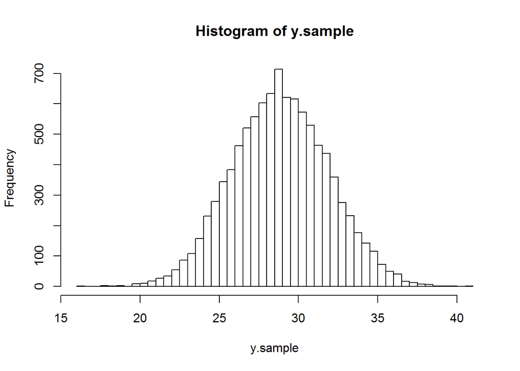

```r
hist(y.sample, breaks=50)
```

# 4. RMSE and Cross Validation

Both a commonly used procedure to calcuate the error rate of the model. if you are interested, I have an Azure ML experiment for Edx Data Science and Machine Learning Course Lab1 published [here](https://t.co/XROnTIOM0r) for comparing the Bayesian Linear Regression and Classical Regression. (disclaimer: it was created for fun, not for real consumption, I was able to do that because the course does not score labs.. yeee)

I just love this picture of explaining the type of errors.

[figure not shown]